# COMPSCIX 415.2 Homework 7 SOLUTION

Robert Clements

DUE DATE: Mar 20, 2018 @ 6:15PM

### Exercise 1

Load the train.csv dataset into R. How many observations and columns are there?

```r
dim(train)
```

```
## [1] 1460   81
```

There are 1460 rows and 81 columns.

### Exercise 2

Normally at this point you would spend a few days on EDA, but for this homework we will get right to fitting some linear regression models.

Our first step is to randomly split the data into train and test datasets. We will use a 70/30 split. There is an R package that will do the split for you, but let’s get some more practice with R and do it ourselves by filling in the blanks in the code below.

```r
# load packages
library(tidyverse)
library(broom)
# When taking a random sample, it is often useful to set a seed so that
# your work is reproducible. Setting a seed will guarantee that the same
# random sample will be generated every time, so long as you always set the
# same seed beforehand
set.seed(29283)

# This data already has an Id column which we can make use of
# let's create our training set using sample_frac. Fill in the blank.
train_set <- train %>% sample_frac(.7)

# let's create our testing set using the Id column. Fill in the blank.
test_set <- train %>% filter(!(Id %in% train_set$Id))
```

### Exercise 3

Our target is called `SalePrice`. First, we can fit a simple regression model consisting of only the intercept (the average of `SalePrice`). Fit the model and then use the broom package to

- take a look at the coefficient,
- compare the coefficient to the average value of `SalePrice`, and
- take a look at the R-squared.

Use the code below and fill in the blanks.

```r
# Fit a model with intercept only
mod_0 <- lm(SalePrice ~ 1, data = train_set)

# Double-check that the average SalePrice is equal to our model's coefficient
mean(train_set$SalePrice)
```

```
## [1] 182176
```

```r
tidy(mod_0)
```

| term | estimate | std.error | statistic | p.value |
| --- | --- | --- | --- | --- |
| (Intercept) | 182176 | 2492.072 | 73.10222 | 0 |

```r
# Check the R-squared
glance(mod_0)
```

| r.squared | adj.r.squared | sigma | statistic | p.value | df | logLik | AIC | BIC | deviance | df.residual |
| --- | --- | --- | --- | --- | --- | --- | --- | --- | --- | --- |
| 0 | 0 | 79668.37 | NA | NA | 1 | -12983.57 | 25971.13 | 25980.99 | 6.480338e+12 | 1021 |

### Exercise 4

Now fit a linear regression model using `GrLivArea`, `OverallQual`, and `Neighborhood` as the features. Don’t forget to look at `data_description.txt` to understand what these variables mean. Ask **yourself** these questions before fitting the model:

- What kind of relationship will these features have with our target?
- Can the relationship be estimated linearly?
- Are these good features, given the problem we are trying to solve?

After fitting the model, output the coefficients and the R-squared using the `broom` package.

Answer these questions:

- How would you interpret the coefficients on `GrLivArea` and `OverallQual`?
- How would you interpret the coefficient on `NeighborhoodBrkSide`?
- Are the features *significant*?
- Are the features *practically significant*?
- Is the model a good fit (to the training set)?

```r
mod_1 <- lm(SalePrice ~ GrLivArea + OverallQual + Neighborhood, data = train_set)
glance(mod_1)
```

| r.squared | adj.r.squared | sigma | statistic | p.value | df | logLik | AIC | BIC | deviance | df.residual |
| --- | --- | --- | --- | --- | --- | --- | --- | --- | --- | --- |
| 0.8099927 | 0.8050277 | 35178.1 | 163.1401 | 0 | 27 | -12134.95 | 24325.91 | 24463.93 | 1.231311e+12 | 995 |

```r
tidy(mod_1)
```

| term | estimate | std.error | statistic | p.value |
| --- | --- | --- | --- | --- |
| (Intercept) | -45017.87483 | 12933.341808 | -3.4807612 | 5.216927e-04 |
| GrLivArea | 62.77735 | 3.006033 | 20.8837885 | 1.337222e-80 |
| OverallQual | 21692.23178 | 1353.714104 | 16.0242342 | 1.389020e-51 |
| NeighborhoodBlueste | -38288.88063 | 36531.907177 | -1.0480942 | 2.948497e-01 |
| NeighborhoodBrDale | -43314.05372 | 14524.693991 | -2.9820975 | 2.932566e-03 |
| NeighborhoodBrkSide | -14064.37052 | 11318.850018 | -1.2425618 | 2.143221e-01 |
| NeighborhoodClearCr | 27839.00662 | 13561.346871 | 2.0528202 | 4.035110e-02 |
| NeighborhoodCollgCr | 4297.67432 | 10372.304467 | 0.4143413 | 6.787135e-01 |
| NeighborhoodCrawfor | 7423.05573 | 11371.511784 | 0.6527765 | 5.140512e-01 |
| NeighborhoodEdwards | -15284.11495 | 10994.287187 | -1.3901870 | 1.647830e-01 |

[output cut: 17 more lines]

For every extra square foot in the above ground living area, the sale price increases, on average, by $62, with all other features being held constant. For every one unit increase in the overall quality of the house (as this value goes up, the quality is higher), the mean increase in the sale price is $21700.

The mean difference in the sale price between Bloomington Heights and Brookside is -$14064, so Brookside is a less expensive area to live.

Both GrLivArea and OverallQual are both statistically and practically significant. For neighborhood, many of the categories are significant (both statistically and practically), and some are not statistically significant.

Based on the adjusted R-squared (.80), the model seems to be a good fit to the data.

### Exercise 5

Evaluate the model on `test_set` using the root mean squared error (RMSE). Use the `predict` function to get the model predictions for the testing set. Recall that RMSE is the square root of the mean of the squared errors:

$$\sqrt{\frac{1}{n}\sum_{i=1}^{n}(\text{SalePrice}_{i} - \hat{\text{SalePrice}}_{i})^2}$$

Hint: use the `sqrt()` and `mean()` functions:

```r
test_predictions <- predict(mod_1, newdata = test_set)
rmse <- sqrt(mean((test_set$SalePrice - test_predictions)^2))
rmse
```

```
## [1] 41915.27
```

### Exercise 6 (OPTIONAL - won’t be graded)

Feel free to play around with linear regression. Add some other features and see how the model results change. Test the model on `test_set` to compare the RMSE’s.

### Exercise 7

One downside of the linear model is that it is sensitive to unusual values because the distance incorporates a squared term. Fit a linear model to the simulated data below, and visualise the results. Rerun a few times to generate different simulated datasets. What do you notice about the model?

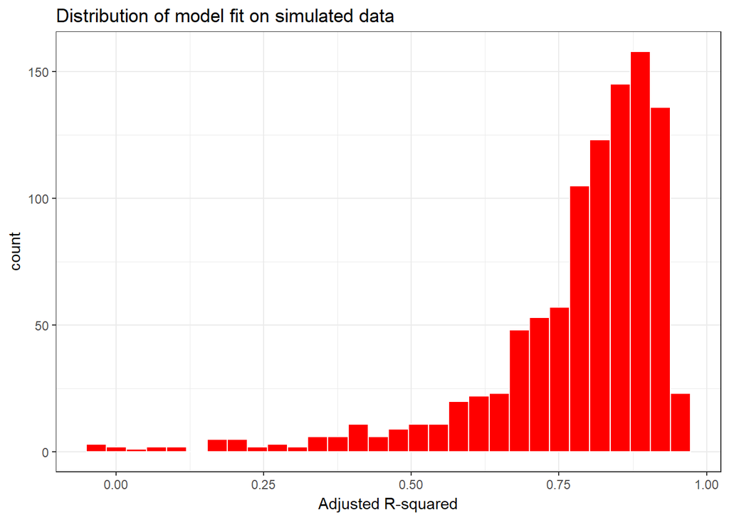

```r
# create a function that will simulate data;
# fit a regression model
# extract the adjusted r-squared
# extract the slope (coefficient on x)
# return a tibble with the adjusted r-squared and slope
collect_results <- function(sim_data) {
  sim1a <- tibble(
  x = rep(1:10, each = 3),
  y = x * 1.5 + 6 + rt(length(x), df = 2)
  )

  sim_mod <- lm(y ~ x, data = sim1a)
  rsq <- glance(sim_mod) %>% .[['adj.r.squared']]
  slopes <- tidy(sim_mod) %>% filter(term == 'x') %>% .[['estimate']]
  tibble(rsq, slopes)
}

# define iter to do 1000 simulations
iter <- 1:1000

# use the map_dfr function to map the function above to the iter
# vector. Basically, run the function 1000 times and collect all
# of the results into a data.frame
mod_results <- map_dfr(iter, collect_results)

# visualize the distributions of the adjusted R-squared and the slopes
mod_results %>% ggplot(aes(x = rsq)) +
  geom_histogram(color = 'white', fill = 'red') +
  labs(x = 'Adjusted R-squared', title = 'Distribution of model fit on simulated data') +
  theme_bw()
```

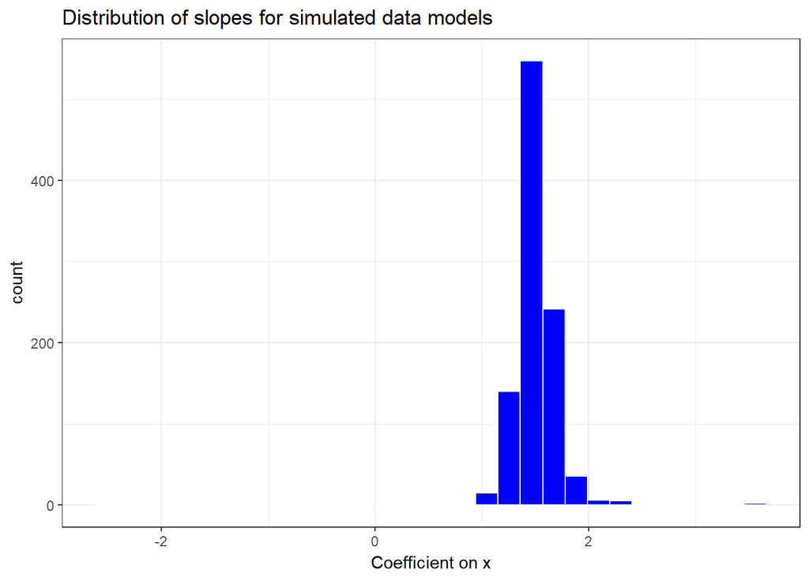

```r
mod_results %>% ggplot(aes(x = slopes)) +
  geom_histogram(color = 'white', fill = 'blue') +
  labs(x = 'Coefficient on x', title = 'Distribution of slopes for simulated data models') +
  theme_bw()
```

From the distributions of the adjusted R-squared and the slopes above, we can see that even when we simulate data from a known model, the slope and the model fit can vary widely simply because of slight changes in the data. This illustrates how sensitive regression can be.